# A Brief Analysis of the Vector Autoregressive Model and its Applications

Rock Pang and Leo Li

## 1. Introduction

The Vector Autoregressive (VAR) model is one of the most flexible models for the analysis of multivariate time series (Zivot and Wang 2006). Introduced by Christopher A. Sims, a Nobel Prize winner in economics, it has been heavily used in building econometric models (C. A. Sims 1980). Previous literature has studied the correlation of public investment and Gross Domestic Product (Mittnik and Neumann 2001), the market response to the a company’s marketing mix (Srinivasan, Vanhuele, and Pauwels 2010), and pass-through effects of exchange rate changes to domestic price (Ito and Sato 2008), etc.

As autoregressive (AR) model use specific lagged values of $X_t$ as predictors, the VAR model is essentially a combination of univariate AR models. An unique feature of VAR is that a variable depends on not only its own lagged values but also those of other variates in the multivariate vector, and error terms. The problem it tries to tackle is that multiple time series may impact each other at the same time instead of treating an univariate time series as independent. VAR is a complex model to forecast, and one should not think that this method can only be applied to economics. VAR model has been also effective in predicting rainfall (Nugroho, Hartati, and Mustofa 2014), studying of chemical property (Nugroho, Hartati, and Mustofa 2014), and forecasting traffic flow (Kamarianakis and Prastacos 2003), for example.

This tutorial aims to provide detailed introduction of VAR model. In Section 2, we introduce the model. We also discuss the Impulse Response Function and Forecast Error Variance Decomposition, which capture the model’s dynamic behaviors. In Section 3, we illustrate the VAR model in a real-world example of comparing stock market in mainland China, Hong Kong, the United Kingdom, and the United States. This section contains many useful R codes and graph interpretation. We provide concluding remarks on the advantages and disadvantages of VAR models in general. Then, we discuss how to make more complex models such as Structural VAR model and Bayesian VAR model.

## 2. Vector Autoregressive Model

VAR models are used for multi-variate time series analysis. As you might recall, an AR(1) model is stated $X_t = \delta + \phi_1X_{t-1}+\epsilon_t$, where $\delta$ is a constant, $\phi_1$ is the AR coefficient, and $\epsilon_t \stackrel{iid}{\sim} N(0, \sigma_w^2)$ is independent Gaussian white noise with mean 0 and constant variance. In a VAR model, each variable is a linear function of its past lags and past lags of all other variables. A VAR model of lag one, denoted as VAR(1), can be written as the following equations if we consider two time series variables $x_1$ and $x_2$:

$$X_{1,t} = \delta_1 + \phi _{1,1}X_{1,t-1} + \phi _{1,2}X_{2,t-1} + \epsilon_{1,t} \\ X_{2,t} = \delta_2 + \phi _{2,1}X_{1,t-1} + \phi _{2,2}X_{2,t-1} + \epsilon_{2,t}$$

Similarly with the same variables, a VAR(2) model can be written as:

$$X_{1,t} = \delta_1 + \phi _{1,1}X_{1,t-1} + \phi _{1,2}X_{2,t-1} + \phi^2 _{1,1}X_{1,t-2} + \phi^2 _{1,2}X_{2,t-2} + \epsilon_{1,t} \\ X_{2,t} = \delta_2 + \phi_{2,1}X_{1,t-1} + \phi_{2,2}X_{2,t-1} + \phi^2_{2,1}X_{1,t-2} + \phi^2_{2,2}X_{2,t-2} + \epsilon_{2,t}$$

where $\alpha$ is the constat, $\epsilon$ is the error term and $\phi^{p} _{i,j}$ denotes the coefficient that explains the relationship between variables $i$ and $j$ at the $p^{th}$ lag. Note that the notation $\phi_{i,j}^p$ does not indicate the squaring of the coefficient and simply means that the number of lags is equal to $p$.

Putting the equations above in the matrix form, we get a VAR(2) model as shown below:

$$\begin{pmatrix}
X_{1,t}\\
X_{2,t}\\
\end{pmatrix}
=
\begin{pmatrix}
\alpha_1\\
\alpha_2\\
\end{pmatrix}
+
\begin{array}{ccc}
\begin{pmatrix}
\phi _{1,1} & \phi _{1,2}\\
\phi _{2,1} & \phi _{2,2}\\
\end{pmatrix}
\begin{pmatrix}
X_{1,t-1} \\
X_{2,t-1} \\
\end{pmatrix}
\end{array}
+
\begin{pmatrix}
\phi^2 _{1,1} & \phi^2 _{1,2}\\
\phi^2 _{2,1} & \phi^2 _{2,2}\\
\end{pmatrix}
\begin{pmatrix}
X_{1,t-2} \\
X_{2,t-2} \\
\end{pmatrix}
+
\begin{pmatrix}
\epsilon_{1,t}\\
\epsilon_{2,t}\\
\end{pmatrix}$$

To generalize, a $VAR(p)$ model with $m$ time series variables will have the following form:

$$\begin{pmatrix}
X_{1,t}\\
X_{2,t}\\
\vdots\\
X_{m,t}
\end{pmatrix}
=
\begin{pmatrix}
\alpha_1\\
\alpha_2\\
\vdots\\
\alpha_m\\
\end{pmatrix}
+
\sum_{k=1}^p
\begin{pmatrix}
\phi^k _{1,1} & \phi^k _{1,2} & ... & \phi^k_{1,m}\\
\phi^k _{2,1} & \phi^k _{2,2} & ... & \phi^k_{2,m}\\
\vdots & \vdots & \ddots & \vdots\\
\phi^k _{m,1} & \phi^k _{m,2} & ... & \phi^k_{m,m}\\
\end{pmatrix}
\begin{pmatrix}
X_{1,t-k} \\
X_{2,t-k} \\
\vdots\\
X_{m,t-k}
\end{pmatrix}
+
\begin{pmatrix}
\epsilon_{1,t}\\
\epsilon_{2,t}\\
\vdots\\
\epsilon_{m,t}
\end{pmatrix}$$
Similarly, the $k$ in the power denotes the number of lags and $\phi^k_{i,j}$ characterize the relationship between $i$ and $j$ at lag $k$. Note that the summation indicates that for each lag, we would have a unique coefficient matrix and our VAR model includes $p$ coefficient matrices in total.

The coefficients in the VAR model can be estimated using both Ordinary Least Square and Maximum Likelihood Estimation. In most cases we use MLE instead of OLS but if we assume the errors to be normally distributed, both the OLS and MLE will give us the same results. The interpretation of the coefficient is similar to how we interpret a regular AR model: if $X_j$ increases by 1 at the $k^{th}$ lag, then we would expect $X_i$ to change by the amount of $\phi^k_{i,j}$ controlling for other variables. However as we can see from the coefficient matrix above, there are too many things going on and the change in one variable is determined by all other variable in different lag periods. Thus interpreting a single coefficient in the VAR model cannot give us much information and that’s mainly why we have to go for a another path that could combine all the information in our model to make estimation. The most common tools associated with the VAR model are the Impulse Response Function and the Forecast Error Variance Decomposition, which we will discussed in the next section.

### 2.1 Impulse Response Function & Forecast Error Variance Decomposition

Once we have a VAR model estimated, we can generate a Impulse Response Function graph to evaluate the dynamics of the system as a whole. Parameters in our VAR models only provide limited information because all variables depend on each other (Mohr 2018). An Impulse Response function deals with the tight correlations. If there’s a one-unit shock (a one standard-deviation increase) in the error term of variable (j) at a specific time (t) $\epsilon_{j,t}$, how would the response variable change accordingly. The impulse response is defined as the derivative of the response value with respect to $\epsilon_{j,t}$. Before delving into more details, recall that AR(p) can be written as an infinite-order MA model. Similarly, VAR can also be rewritten as VMA($\infty$). It We use VAR(1), rewritten as VMA($\infty$) by successive substitution, as an example to prove the the response change $\boldsymbol{X_{t}}$ to a shock.

$$\frac{\partial{\boldsymbol{X_{t}}}}{\partial{{\epsilon_{j,t-1}}}} = \frac{\partial}{\partial{\epsilon_{j,t-1}}}(\boldsymbol{\Phi} \boldsymbol{X_{t-1}} + \boldsymbol{\epsilon_{t}}) = \frac{\partial}{\partial{\epsilon_{j,t-1}}} (\boldsymbol{\Phi}(\boldsymbol{\Phi} \boldsymbol{X_{t-2}} + \boldsymbol{\epsilon_{t-1}}) + \boldsymbol{\epsilon_{t}}) = ... = \frac{\partial}{\partial{\epsilon_{j,t-1}}} (\sum_{i=0}^\infty \boldsymbol{\Phi^i \epsilon_{t-i}}) = \boldsymbol{\Phi} e_j$$

In the equation above, $\boldsymbol{\Phi}$ is the coefficient matrix of VAR(1), which denotes
$$\boldsymbol{\Phi} =
\begin{pmatrix}
\phi_{1,1} & \phi_{1,2} & \dotsi & \phi_{1,m}\\
\phi_{2,1} & \phi_{2,2} & \dotsi & \phi_{2,m}\\
\vdots & \vdots &\ddots & \vdots\\
\phi_{m,1} & \phi_{m,2} & \dotsi & \phi_{m,m}
\end{pmatrix}$$

Therefore, the response of a specific value $X_{i,t}$ to one-time impulse in $X_{i,t-1}$ hold constant. The response of variable $i$ to a unit shock in variable $j$ is sometimes depicted graphically to get a visual impression of the dynamic inter-relationship within the system (Rossi 2011).

To make the Impulse Response Function more refined, we can consider the Orthogonal Impulse Response Function (OIRF). One of the major limitations of the Impulse Response Function is the assumption that there is only a shock to $\epsilon_{j,t}$ while other terms remain independent. However in most of the cases, a shock to $\epsilon_{j,t}$ will also lead to a simultaneous shock to $\epsilon_{i,t}$. As a result, it is hard to measure how much of the response in $X_{j,t}$ is caused by the shock in $\epsilon_{j,t}$. In other words, correlation of the error terms may indicate that a shock in one variable is likely to be accompanied by a shock of another variable. Hence we have to eliminate these shocks by using the OIRF (Koop, Pesaran, and Potter 1996). OIRF makes sure that each impulse has no effect on other components because the they are orthogonal.

In R, we can plot this using `plot(irf(var_model_name))` to visualize how each variable responds to one shock. We further discuss this in Section 3. One thing to keep in mind, if the plot is stable and close to zero, that means one unit shock in $x_{i,t}$ has small effect on the other variables at future time.

We can also generate a Forecast Error Variance Decomposition (FEVD) graph based on the VAR model, which shows what portion of the variance of the forecasting errors in predicting a response variable is due to a shock in the impulse variable. It is one way to quantify how important each shock is in explaining the variation in each of the variables in the system (E. Sims, n.d.). The FEVD allows the user to analyze the contribution of variable j to the variance of forecasting error in variable k. The R function will print a bar graph, the larger the portion, the influence of that variable is contributing the most to the forecast uncertainty of the variable of our concern. Section 3 illustrates a specific example of four global stock markets. A rigorous description can be found [here](https://faculty.washington.edu/ezivot/econ584/notes/varModels.pdf).

## 3. Applications of VAR

VAR models are used extensively in Economics, in which people use techniques such as VAR to conduct causality tests. In this section, we aim to apply the VAR model to estimate the cointegration between different stock markets. Manning (2002) conducted a similar study using the VAR model. He collected data on eight major stock markets in the Southeast Asia and found that there was an increasing integration between these markets from 1988 to 1990 and from 1992 to mid-1997. Here we seek to replicate this study but broaden our horizon to the global stock markets.

**Step 1**

You should follow this command below to load your data and create time series of your interest. Note that the VAR model in R does not allow NA value, so in this tutorial we approximate the data during the weekends and holidays in different countries by na.approx in library zoo.

```r
library(vars)
library(astsa)
library(zoo)

data <- read_excel("official data2.xlsx", skip = 1)
stocks <- data %>% select(c("s&p500return", "SSEreturn", "HSIreturn", "ftsereturn"))

# US stock market
sp500 <- na.approx(ts(stocks[,1], start=decimal_date(as.Date("2015-12-01")), end=c(2018, 12), frequency=365))
# Mainland China stock market
sse <- na.approx(ts(stocks[,2], start=decimal_date(as.Date("2015-12-01")), end=c(2018, 12), frequency=365))
# Hong Kong stock market
hsi <- na.approx(ts(stocks[,3], start=decimal_date(as.Date("2015-12-01")), end=c(2018, 12), frequency=365))
# The UK stock market
ftse <- na.approx(ts(stocks[,4], start=decimal_date(as.Date("2015-12-01")), end=c(2018, 12), frequency=365))
```

Then we can visualize our initial time series after combining our time series.

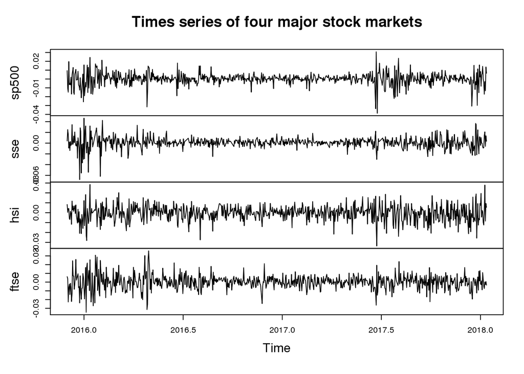

```r
x = cbind(sp500, sse, hsi, ftse)
plot.ts(x , main = "Times series of four major stock markets")
```

The y-axis measures the daily return of each market as we have mentioned above. If it is 0.02, then it indicates that this market increases by 2% in that coresponding trading day.

**Step 2**

Theoretically, we have infinite choices of lags, so we would like to use to make a VAR model, we should choose the reasonable lag before delving into the model. In R, `VARselect()` function will do it for you:

```r
VARselect(x, type = "both")
```

```
## $selection
## AIC(n)  HQ(n)  SC(n) FPE(n)
##      4      1      1      4
##
## $criteria
##                    1             2             3             4
## AIC(n) -3.915668e+01 -3.915204e+01 -3.915141e+01 -3.919124e+01
## HQ(n)  -3.910052e+01 -3.905844e+01 -3.902037e+01 -3.902276e+01
## SC(n)  -3.901082e+01 -3.890894e+01 -3.881106e+01 -3.875365e+01
## FPE(n)  9.873468e-18  9.919435e-18  9.925822e-18  9.538434e-18
##                    5             6             7             8
## AIC(n) -3.918548e+01 -3.917812e+01 -3.919031e+01 -3.918379e+01
## HQ(n)  -3.897957e+01 -3.893476e+01 -3.890952e+01 -3.886556e+01
## SC(n)  -3.865065e+01 -3.854604e+01 -3.846099e+01 -3.835723e+01
## FPE(n)  9.593751e-18  9.665102e-18  9.548464e-18  9.611640e-18
##                    9            10
## AIC(n) -3.917549e+01 -3.915601e+01
## HQ(n)  -3.881981e+01 -3.876289e+01
## SC(n)  -3.825168e+01 -3.813496e+01
## FPE(n)  9.692692e-18  9.884517e-18
```

We can observe four criteria included above. A more detailed comparison can be found [here](https://sccn.ucsd.edu/wiki/Chapter_3.5._Model_order_selection). AIC is the most widely used among the four. However, it is a good practice to select the lag value by examining these criteria and combining this information with additional knowledge specific to the problem (Mullen 2014). Given that each criterion may give different optimal lags, it is in our advantage to fit the models with lags that each criterion suggest and compare them based on our specific context. Using our data, these criteria suggest one-period lag or four-period lag. Considering that we are evaluating stock markets, it makes more sense to use `lag=1` given the sponteity of the markets. For instance, the performance of the stock markets at t=1 is highly likely to be correlated with the performance in the next day while the influence will mitigate as we go further. Thus the markets at t=1 are less likely to influence the performance at t=4, and thus a one-period lag is analyzed in this specific context.

In the following R chunk, the `p` parameter is the lag we choose. An interesting parameter is `type` which denotes the type of deterministic regressors to include. There are four options `const`, which stands for constant (or intercept in the model); `trend`, which considers the trend of the original series; `both` which includes both constant and trend; or `none` which includes neither. The choice should also depends on context. In this case, our time series does not seem to have a clear trend, so we use `const`. (Please see the Appendix for model summary)

```r
fitvar1=VAR(x, p=1, type= "const")
```

**Step 3**

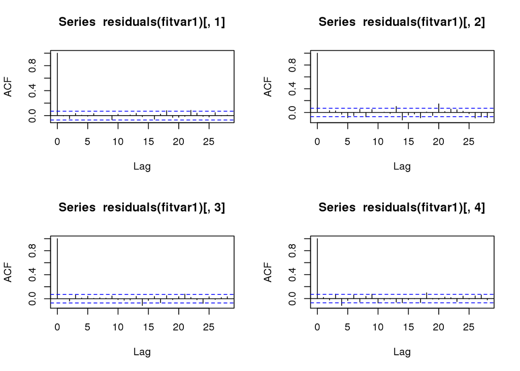

```r
par(mfrow = c(2,2))
acf(residuals(fitvar1)[,1]) #sp500
acf(residuals(fitvar1)[,2]) #sse
acf(residuals(fitvar1)[,3]) #hsi
acf(residuals(fitvar1)[,4]) #ftse
```

**Step 4**

Then we can generate Impulse Response functions to describe the response of the four output to an impulse of one stock market in our example. The four OIRF graphs show that based on our data, if there is one-unit shock to one market, how would the other markets respond. Recall that in Section 2.1 by taking the derivative we showed that a one-unit impulse in $X_i$ will lead to a certain amount of change in $X_j$ in the first lag period. While our proof only demonstrates this pattern for the first lag but for other lag periods the proof is the same and each lag period has an associated coefficient that determines the amount of change in $X_j$ in this period if an impulse is given to $X_i$. Here in our example, the x-axis is lag which is one day in this case. The y-axis shows by how much each market would react in each lag period if we impose a one-unit shock to a market at lag $t=0$.

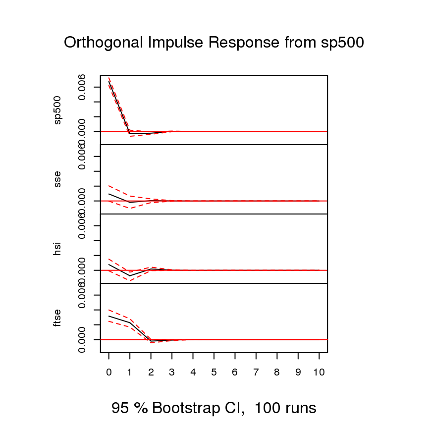

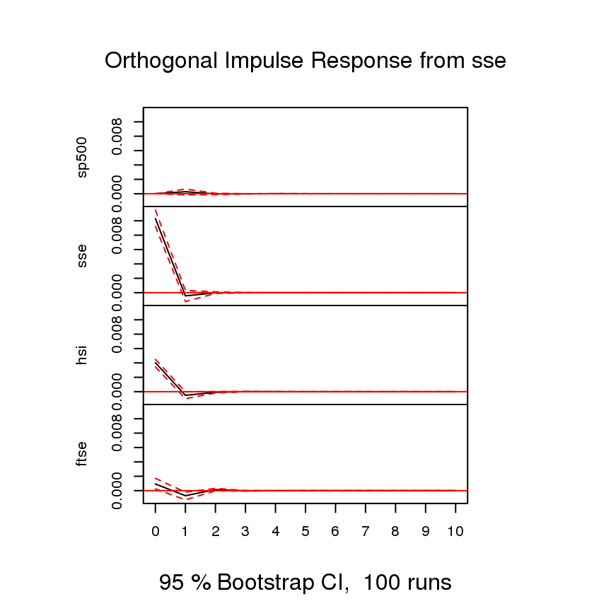

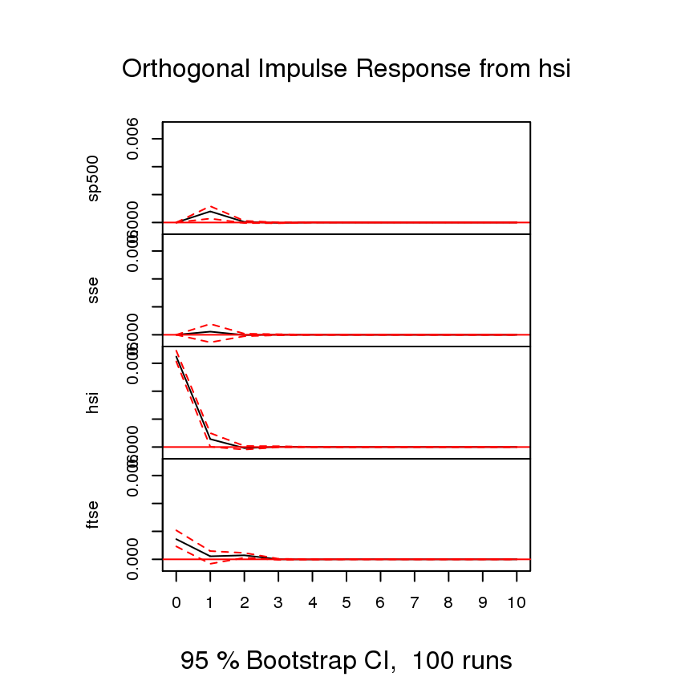

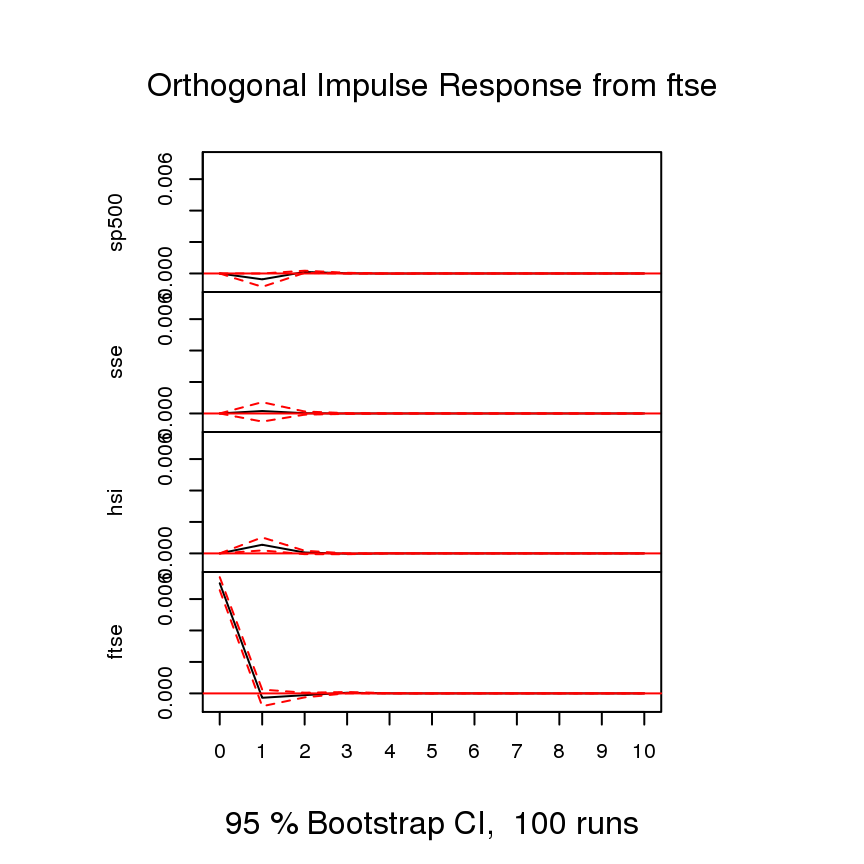

```r
par(mfcol = c(2, 2))
plot(irf(fitvar1, impulse = "sp500", ortho = TRUE))
plot(irf(fitvar1, impulse = "sse", ortho = TRUE))
plot(irf(fitvar1, impulse = "hsi", ortho = TRUE))
plot(irf(fitvar1, impulse = "ftse", ortho = TRUE))
```

From the second graph we can see that a shock to the SSE (mainland China) will have a significant influence on the HSI (Hong Kong) while not impacting the other two markets. This observation also makes sense given that the mainland China and Hong Kong are closely related to each other and given the larger volume of the Shanghai Stock Exchange, it’s very likely to impact Hong Kong stock market.

Based on the last graph, we notice that an impulse in the FTSE (Britain) will not have any major impact on the other three markets, which makes sense because among these four markets the British market has the smallest volume and thus it is unlikely to influce other bigger markets.

**Step 5**

Then, we can generate the Forecast Error Variance Decoposition (FEVD) to determine the influence of each shocks by looking at the portion of each stock market in the bar graph.

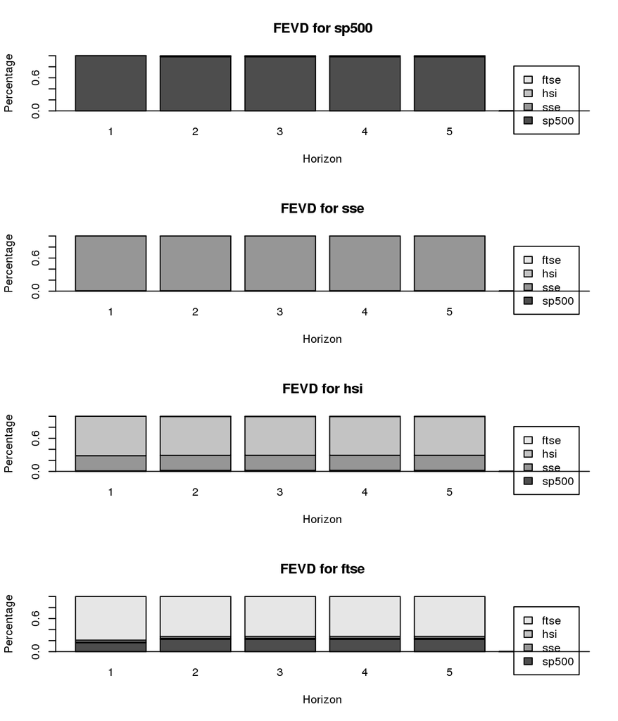

```r
plot(fevd(fitvar1, n.ahead = 5))
```

**Step 6**

Finally, we can predict the next few days of stock price changes in the next few days based on our VAR model. This is our ultimate goal in variable prediction using VAR after considering the correlations between multiple time series. Below are codes and nice picture of the predictions of the stock price changes in the next 5 days.

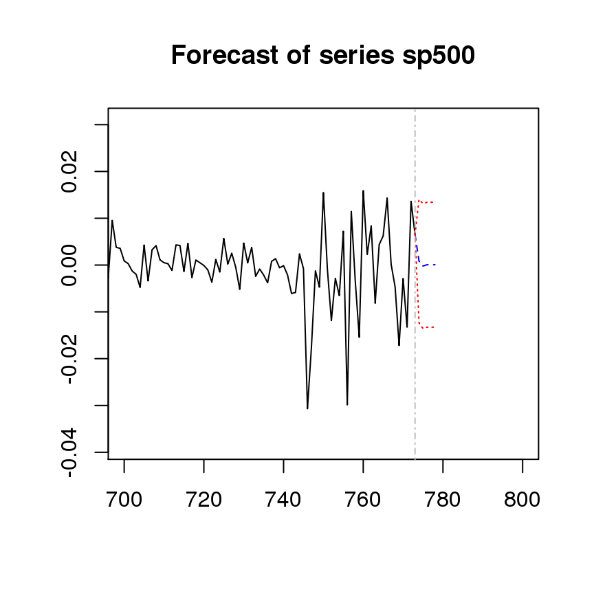

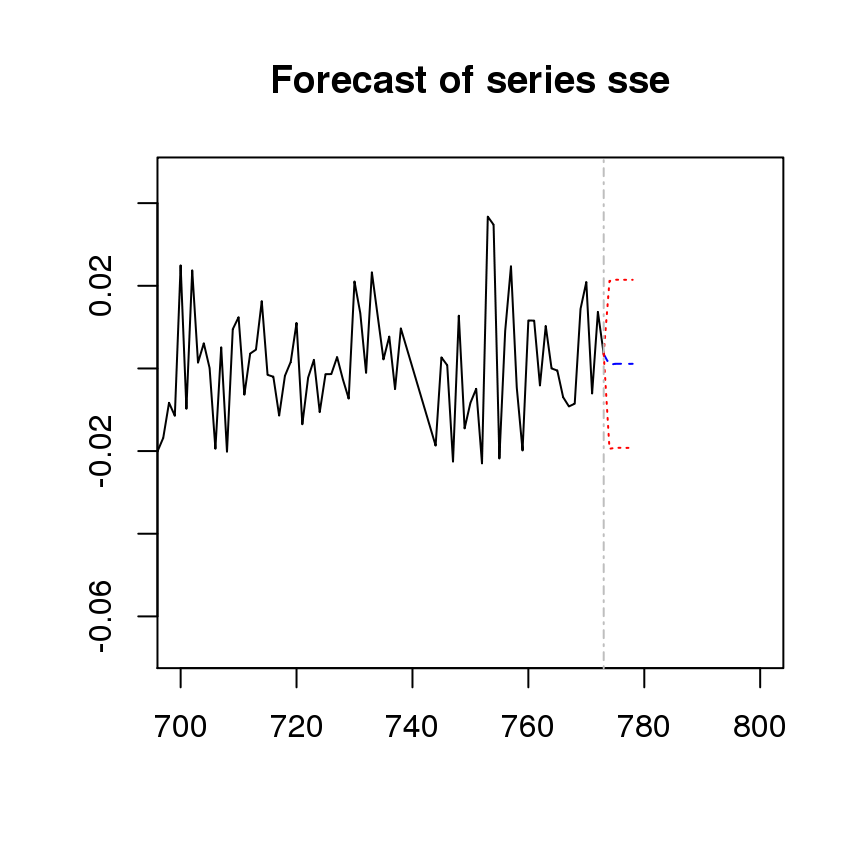

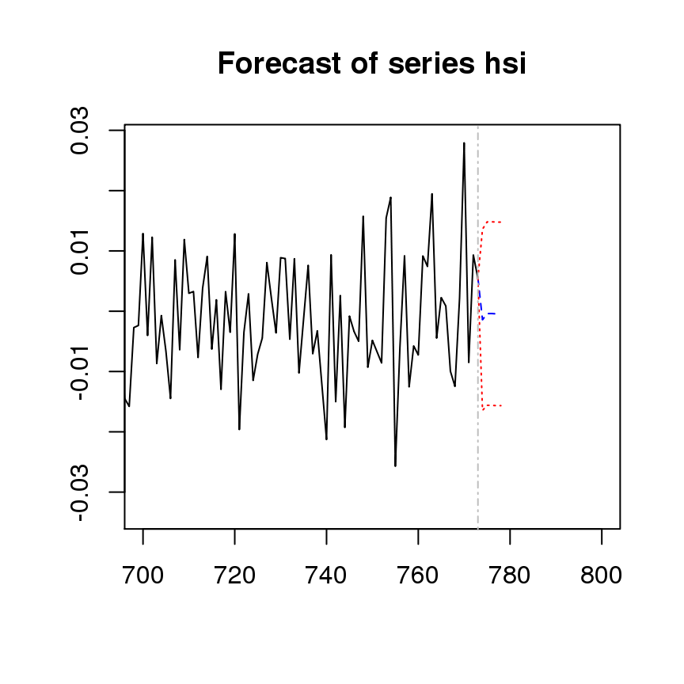

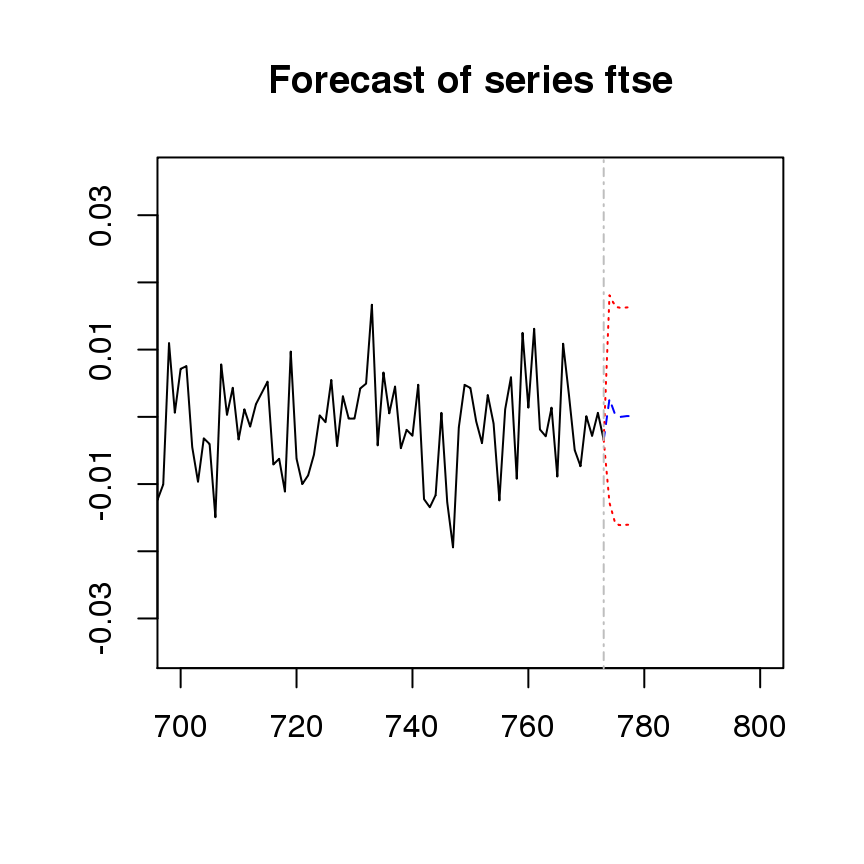

```r
par(mfrow = c(2,2))
predictions <- predict(fitvar1, n.ahead = 5, ci = 0.95)
plot(predictions, xlim = c(700, 800), names = "sp500")
plot(predictions, xlim = c(700, 800), names = "sse")
plot(predictions, xlim = c(700, 800), names = "hsi")
plot(predictions, xlim = c(700, 800), names = "ftse")
```

## 4. Conclusion

The tutorial poject provides an overview on the VAR Model, the asociated Impulse Response Function and Forecast Error Variance Decomposition. Then we apply these techniques in a real world setting and try to figure out the cointegration of the four major stock markets. VAR models are useful tools in many fields in that it evaluates multivariate time series and checks their influence on each other at different lags. It models the dynamic response to shocks in the Impulse Response function. It can aid identification of shocks and determines the corresponding effects on other variables after a certain period of time. This is especially informative in analyzing policy shocks to form an economic policy. It is often considered good for short-term forecasting.

VAR, however, has its disadvantages too. When we add more variables in the model, the number of parameters goes rapidly. If we fit too many variables and lags in the model, it also tend to be overfitting. Multicollinearity can also become a serious problem as more series and lagged values of series are added to the model. It can be very difficult to separate the effects between variables.

The flexibility of the VAR model enables it to be modified in some cases into a Structural VAR model or a Bayesian VAR model depending on our objectives. Compared to the regular VAR model, a Structural VAR model assumes that every error term has mean zero and there is no correlation between each error term across time. With that being said, the off-diagonal entries in the covariance matrix of a SVAR model are all zero. In other words, a SVAR better isolate the serial correlation in our data and thus it is more often used in evaluating economic policies when we have to control for correlation and multicollinearity.

Similarly to the gap between Bayesian Statistics and Frequentist, a Bayesian VAR model views the model parameters as random variables and takes into account a prior information. In our example, a Bayesian VAR model may have a better estimation because we have a strong prior knowledge in the fact that larger markets tend to impact smaller markets. What’s more interesting, in macroeconomics one of the most commonly used priors in the BVAR model is called the “Minnesota Prior”, in which we assume that the coefficients in the model follow a “random walk” bahavior and normal distribution given the randomness of most economic data.

In short, the VAR model has become one of the most prevalent techniques in the time series analysis. We hope that this tutorial project may have offered you some insights into the time series analysis not only in economics but also many other fields.

## Appendix

More functions related to VAR model are available on [R Documentation](https://www.rdocumentation.org/packages/vars/versions/1.5-3)

```r
summary(fitvar1)
```

```
##
## VAR Estimation Results:
## =========================
## Endogenous variables: sp500, sse, hsi, ftse
## Deterministic variables: const
## Sample size: 772
## Log Likelihood: 10739.116
## Roots of the characteristic polynomial:
## 0.2103 0.2103 0.09016 0.0315
## Call:
## VAR(y = x, p = 1, type = "const")
##
##
## Estimation results for equation sp500:
## ======================================
## sp500 = sp500.l1 + sse.l1 + hsi.l1 + ftse.l1 + const
##
##            Estimate Std. Error t value Pr(>|t|)
## sp500.l1 -0.0251069  0.0385163  -0.652 0.514693
## sse.l1   -0.0207885  0.0277176  -0.750 0.453478
## hsi.l1    0.1345083  0.0375391   3.583 0.000361 ***
## ftse.l1  -0.0532847  0.0324247  -1.643 0.100724
## const     0.0001583  0.0002461   0.643 0.520150
## ---
## Signif. codes:  0 '***' 0.001 '**' 0.01 '*' 0.05 '.' 0.1 ' ' 1
##
##
## Residual standard error: 0.006738 on 767 degrees of freedom
## Multiple R-Squared: 0.02094, Adjusted R-squared: 0.01583
## F-statistic: 4.101 on 4 and 767 DF,  p-value: 0.002701
##
##
## Estimation results for equation sse:
## ====================================
## sse = sp500.l1 + sse.l1 + hsi.l1 + ftse.l1 + const
##
##            Estimate Std. Error t value Pr(>|t|)
## sp500.l1 -0.0337495  0.0592223  -0.570   0.5689
## sse.l1   -0.0565368  0.0426183  -1.327   0.1850
## hsi.l1    0.0296062  0.0577198   0.513   0.6081
```

[output cut: 48 more lines]

```
##
##
## Covariance matrix of residuals:
##           sp500       sse       hsi      ftse
## sp500 4.539e-05 6.367e-06 5.211e-06 2.134e-05
## sse   6.367e-06 1.073e-04 4.225e-05 1.253e-05
## hsi   5.211e-06 4.225e-05 5.882e-05 1.553e-05
## ftse  2.134e-05 1.253e-05 1.553e-05 6.208e-05
##
## Correlation matrix of residuals:
##         sp500     sse    hsi   ftse
## sp500 1.00000 0.09122 0.1008 0.4020
## sse   0.09122 1.00000 0.5318 0.1536
## hsi   0.10085 0.53180 1.0000 0.2570
## ftse  0.40201 0.15356 0.2570 1.0000
```

## Bibliography

Ito, Takatoshi, and Kiyotaka Sato. 2008. “Exchange Rate Changes and Inflation in Post-Crisis Asian Economies: Vector Autoregression Analysis of the Exchange Rate Pass-Through.” *Journal of Money, Credit and Banking* 40 (7). Wiley Online Library: 1407–38.

Kamarianakis, Yiannis, and Poulicos Prastacos. 2003. “Forecasting Traffic Flow Conditions in an Urban Network: Comparison of Multivariate and Univariate Approaches.” *Transportation Research Record* 1857 (1). SAGE Publications Sage CA: Los Angeles, CA: 74–84.

Koop, Gary, M Hashem Pesaran, and Simon M Potter. 1996. “Impulse Response Analysis in Nonlinear Multivariate Models.” *Journal of Econometrics* 74 (1). Elsevier: 119–47.

Mittnik, Stefan, and Thorsten Neumann. 2001. “Dynamic Effects of Public Investment: Vector Autoregressive Evidence from Six Industrialized Countries.” *Empirical Economics* 26 (2). Springer: 429–46.

Mohr, Franz X. 2018. “An Introduction to Vector Autoregression (Var).” https://www.r-econometrics.com/timeseries/varintro/.

Mullen, T. R. 2014. “EEGLAB, Sift, Nft, Bcilab, and Erica: New Tools for Advanced Eeg Processing.” *Computational Intelligence and Neuroscience*. https://sccn.ucsd.edu/wiki/SIFT.

Nugroho, Adi, Sri Hartati, and Khabib Mustofa. 2014. “Vector Autoregression (Var) Model for Rainfall Forecast and Isohyet Mapping in Semarang–Central Java–Indonesia.” *Editorial Preface* 5 (11). Citeseer.

Rossi, Eduardo. 2011. “Impulse Response Functions.” *Università Di Pavia*.

Sims, Christopher A. 1980. “Macroeconomics and Reality.” *Econometrica: Journal of the Econometric Society*. JSTOR, 1–48.

Sims, Eric. n.d. “Graduate Macro Theory Ii: Notes on Time Series.”

Srinivasan, Shuba, Marc Vanhuele, and Koen Pauwels. 2010. “Mind-Set Metrics in Market Response Models: An Integrative Approach.” *Journal of Marketing Research* 47 (4). SAGE Publications Sage CA: Los Angeles, CA: 672–84.

Zivot, Eric, and Jiahui Wang. 2006. “Vector Autoregressive Models for Multivariate Time Series.” *Modeling Financial Time Series with S-Plus*. Springer, 385–429.